# Multivariable Newton Raphson Method

## This Notebook divided into three parts

### Using Newton Rapson method for solving system of nonlinear equations

### Using Newton Rapson method for solving unconstrained optimisation

### QR factorization using Gram–Schmidt

## Newton Rapson method for solving system of nonlinear equations

**To solve system of nonlinear equations using Newton Raphson method you should write the system in a specific structure , that structure is**

$$\underline{F(\vec{x})}=F(x_1,x_2,\ldots,x_n)= \begin{pmatrix} f_1\\ f_2 \\ \vdots \\ f_n \end{pmatrix} = \underline{0}$$

**where $F$ is a vector containing all functions equal to zero vector**

$W(\vec{x})= \begin{bmatrix} \nabla f_1(\vec{x}) \\ \nabla f_2(\vec{x}) \\ \vdots \\ \nabla f_n(\vec{x}) \end{bmatrix} =\begin{bmatrix} \frac{\partial f_1(\vec{x})}{\partial x_1} \ldots \frac{\partial f_1(\vec{x})}{\partial x_n} \\ \vdots \\ \frac{\partial f_n(\vec{x})}{\partial x_1} \ldots \frac{\partial f_n(\vec{x})}{\partial x_n} \end{bmatrix}$

**Where $W$ is a two dimentional matrix it's Rows are the gradient of functions** **,$W$ must be a nonsingular matrix**

**the iterative equation is**

$\underline{x_{n+1}}=\underline{x_n} - W^{-1}(\underline{x_n})F(\underline{x_n})$

**Before begin solve examples first introduces the user defined function will used in all examples**

```python
#Import libraries
from sympy import *
import sympy as sy
import numpy as np
```

```python
def Get_Jacobian(F,Vars):
  '''this function take fector function , varables as input and
  generate jacobian symbolically! '''

  Jacob=[]

  for fun in F:
    gradient=[]
    for var in Vars:
      gradient.append(fun.diff(var))


    Jacob.append(gradient)

  return Jacob
```

```python
def Results(F_Vec,Jacob_Mat,x_intial,Tolerance,Show='NO'):
  '''this function used to generate each step results take function vector after appling lambdify function
  ,jacobian matrix, intial points , stopping critaria as a tolerance ,show to print results'''
  Num_Of_Iterations=[] # how many iterations it take each x value to achive tolerance
  State=[] #convargence or divargence
  Opt_Solu=[] # set containing optimum x* to problem

  for x in x_intial:
    counter=0
    print(end="\n")
    print("Intial point is",x)
    norm_diff=np.array([10,10]) # any nonzero vector be okay
    while np.max(norm_diff)>Tolerance:# check infinty norm of diffrence between current and previous vector
      current_value=Newton_Raphson(F_Vec,Jacob_Mat,*x)
      norm_diff=np.max(np.abs(x-current_value))
      x=current_value
      counter+=1
      if Show.lower()=="yes":
        print("Iteration {} , the current value {} norm_diff {}".format(counter,current_value,norm_diff))
    Num_Of_Iterations.append(counter)
    if np.isnan(norm_diff):
      print("Divargence!")
      State.append('Divargence')
    else:
      Opt_Solu.append(current_value)
      print("Convargence")
      State.append('Convargence')

  return Num_Of_Iterations,State,Opt_Solu
```

```python
def Newton_Raphson (F,Jacobian,*x_n):
  '''this function generate newton raphson step'''
  a=np.linalg.inv(np.array(Jacobian(*x_n)))
  b=np.array(F(*x_n))
  x_next=x_n-np.matmul(a,b)
  return x_next
```

```python
def Min_func(Obj,Grad,ext_points):
  '''this functions take extreme points and return the x* and f(X*)'''
  x_min=ext_points[0]
  f_min=Obj(*x_min)
  for i in range(len(ext_points)):
    fun=Obj(*ext_points[i])
    print("\n")
    print("extreme point is",ext_points[i])
    print("the gradient at extreme point is",Grad(*ext_points[i]))
    print("the value of objective at tha points=",Obj(*ext_points[i]))
    if fun < f_min:
      f_min=fun
      x_min=ext_points[i]
  print("\n")

  return x_min,f_min
```

```python
def Gram_Schmidt_QR(A):
  '''this function factorize matrix into QR '''
  Q=np.zeros(A.shape)
  R=np.zeros(A.shape)

  for col in range(A.shape[1]):

    u=A[:,col]


    for i in range(col):
      R[i,col]=np.dot(A[:,col],Q[:,i])

      u=u-R[i,col]*Q[:,i]

    Q[:,col]=u/np.linalg.norm(u,2)
    R[col,col]=np.dot(A[:,col],Q[:,col])

  return Q,R
```

## Example 1

### Solve the following system:

### $ f_1(x,y)=x+3logx-y^2=0\\ f_2(x,y)=2x^2-xy-5x+1=0 $

```python
'''this cell used for write the system of equations
for all examples this cell will be change'''
Vars = symbols('x1 x2') #two symbols
x1=Vars[0]
x2=Vars[1]
print("Varibles" ,Vars)
f1=x1+3*log(x1)/log(10)-x2**2 #f1
f2=2*x1**2-x1*x2-5*x1+1 #f2
F=[f1,f2]
print("System functions",F)
```

```
Varibles (x1, x2)
System functions [x1 - x2**2 + 3*log(x1)/log(10), 2*x1**2 - x1*x2 - 5*x1 + 1]
```

```python
Jacobian=Get_Jacobian(F,Vars) # get jacobian matrix symbolically
print("The jacobian = ",Jacobian)
#print((printing.latex(Jacobian)))
```

```
The jacobian =  [[1 + 3/(x1*log(10)), -2*x2], [4*x1 - x2 - 5, -x1]]
```

## Jacobian Matrix

$\left[ \left[ 1 + \frac{3}{x_{1} \log{\left(10 \right)}}, \ - 2 x_{2}\right], \ \left[ 4 x_{1} - x_{2} - 5, \ - x_{1}\right]\right]$

```python
#use lambdify to calculate numerical values
Func_Vec = lambdify(Vars, F,'numpy')
Jacob_Mat=lambdify(Vars,Jacobian,'numpy')
```

```python
#test some points and print each step result
x_intial=np.array([[3.4,2.2],[1,1],[1,-5],[10,10],[2,-10],[2000,2000],[3.4,2.2],[4,4],[1,1],[20,20]])
Tolerance=10**-6
Results(Func_Vec,Jacob_Mat,x_intial,Tolerance,'yes')
```

```
Intial point is [3.4 2.2]
Iteration 1 , the current value [3.48991237 2.26336446] norm_diff 0.08991237047186296
Iteration 2 , the current value [3.48744465 2.26162993] norm_diff 0.0024677228781033733
Iteration 3 , the current value [3.48744279 2.26162863] norm_diff 1.8599497493276829e-06
Iteration 4 , the current value [3.48744279 2.26162863] norm_diff 1.057376408652999e-12
Convargence

Intial point is [1. 1.]
Iteration 1 , the current value [ 0.04805474 -0.09610949] norm_diff 1.0961094864973022
Iteration 2 , the current value [0.1387237 7.0157994] norm_diff 7.1119088830672155
Iteration 3 , the current value [0.12854639 3.32683792] norm_diff 3.6889614779990634
Iteration 4 , the current value [0.1566543  1.32807379] norm_diff 1.9987641253554602
Iteration 5 , the current value [ 0.20384526 -0.02073067] norm_diff 1.348804464766641
Iteration 6 , the current value [ 0.48725855 -5.4758292 ] norm_diff 5.455098531639669
Iteration 7 , the current value [ 0.35102204 -2.65117129] norm_diff 2.8246579146009294
Iteration 8 , the current value [ 0.17652122 -0.97948054] norm_diff 1.671690744225327
Iteration 9 , the current value [0.20717751 0.44246867] norm_diff 1.4219492144956187
Iteration 10 , the current value [ 0.27612882 -1.29438387] norm_diff 1.7368525404333095
Iteration 11 , the current value [0.17627285 0.11438713] norm_diff 1.4087710022083684
Iteration 12 , the current value [ 0.33970871 -3.06262173] norm_diff 3.177008859126321
Iteration 13 , the current value [ 0.31807494 -1.3400406 ] norm_diff 1.7225811296869133
Iteration 14 , the current value [0.14179117 0.10335391] norm_diff 1.4433945093156173
Iteration 15 , the current value [ 0.31293351 -3.13898558] norm_diff 3.242339496493911
Iteration 16 , the current value [ 0.49049215 -1.52427199] norm_diff 1.6147135949671552
Iteration 17 , the current value [-0.23116388  0.24693151] norm_diff 1.7712034951208562
Iteration 18 , the current value [nan nan] norm_diff nan
Divargence!

Intial point is [ 1. -5.]
Iteration 1 , the current value [ 0.8581657  -2.56733721] norm_diff 2.4326627869043285
Iteration 2 , the current value [ 1.28481303 -1.62123053] norm_diff 0.9461066863723848
Iteration 3 , the current value [ 1.45780272 -1.41501581] norm_diff 0.20621471269531222
Iteration 4 , the current value [ 1.4588315  -1.39684551] norm_diff 0.018170303009650945
Iteration 5 , the current value [ 1.45889023 -1.39676701] norm_diff 7.849956458261254e-05
Iteration 6 , the current value [ 1.45889023 -1.39676701] norm_diff 2.2721229342437255e-09
Convargence

Intial point is [10. 10.]
Iteration 1 , the current value [6.13257387 5.43143467] norm_diff 4.568565334117521
Iteration 2 , the current value [4.3357235  3.29723088] norm_diff 2.134203784379078
```

[output cut: 66 more lines]

```
Iteration 16 , the current value [ 0.49049215 -1.52427199] norm_diff 1.6147135949671552
Iteration 17 , the current value [-0.23116388  0.24693151] norm_diff 1.7712034951208562
Iteration 18 , the current value [nan nan] norm_diff nan
Divargence!

Intial point is [20. 20.]
Iteration 1 , the current value [11.02126769 10.35848614] norm_diff 9.641513860263071
Iteration 2 , the current value [6.60554086 5.62381714] norm_diff 4.734669001643268
Iteration 3 , the current value [4.52934921 3.39688174] norm_diff 2.226935401214476
Iteration 4 , the current value [3.69899621 2.49744567] norm_diff 0.899436069137812
Iteration 5 , the current value [3.5005352  2.27674994] norm_diff 0.220695727978518
Iteration 6 , the current value [3.48750057 2.26169826] norm_diff 0.015051675527571362
Iteration 7 , the current value [3.48744279 2.26162863] norm_diff 6.963221794809016e-05
Iteration 8 , the current value [3.48744279 2.26162863] norm_diff 1.4637415723939284e-09
Convargence
```

```
([4, 18, 6, 7, 7, 15, 4, 5, 18, 8],
 ['Convargence',
  'Divargence',
  'Convargence',
  'Convargence',
  'Convargence',
  'Convargence',
  'Convargence',
  'Convargence',
  'Divargence',
  'Convargence'],
 [array([3.48744279, 2.26162863]),
  array([ 1.45889023, -1.39676701]),
  array([3.48744279, 2.26162863]),
  array([ 1.45889023, -1.39676701]),
  array([3.48744279, 2.26162863]),
  array([3.48744279, 2.26162863]),
  array([3.48744279, 2.26162863]),
  array([3.48744279, 2.26162863])])
```

## Example 2

### Solve the following system:

### $ f_1(x_1,x_2,x_3)=3x_1-cos(x_2x_3)-\frac{1}{2}=0 \\ f_2(x_1,x_2,x_3)=x_1^2-81(x_2+0.1)^2+sin(x_3)+1.06=0 \\ f_3(x_1,x_2,x_3)=e^{-x_1x_2}+20x_3+\frac{10\pi-3}{3}=0 $

```python
Vars = symbols('x1 x2 x3')
x1=Vars[0]
x2=Vars[1]
x3=Vars[2]
print("Varibles" ,Vars)
f1=3*x1-cos(x2*x3)-0.5
f2=x1**2 -81*(x2+0.1)**2+sin(x3)+1.06
f3=exp(-x1*x2)+20*x3+(10*pi-3)/3
F=[f1,f2,f3]
print("System functions",F)
```

```
Varibles (x1, x2, x3)
System functions [3*x1 - cos(x2*x3) - 0.5, x1**2 - 81*(x2 + 0.1)**2 + sin(x3) + 1.06, 20*x3 - 1 + 10*pi/3 + exp(-x1*x2)]
```

```python
Jacobian=Get_Jacobian(F,Vars)
print("The jacobian = ",Jacobian)
```

```
The jacobian =  [[3, x3*sin(x2*x3), x2*sin(x2*x3)], [2*x1, -162*x2 - 16.2, cos(x3)], [-x2*exp(-x1*x2), -x1*exp(-x1*x2), 20]]
```

## Jacobian Matrix

$\left[ \left[ 3, \ x_{3} \sin{\left(x_{2} x_{3} \right)}, \ x_{2} \sin{\left(x_{2} x_{3} \right)}\right], \ \left[ 2 x_{1}, \ - 162 x_{2} - 16.2, \ \cos{\left(x_{3} \right)}\right], \ \left[ - x_{2} e^{- x_{1} x_{2}}, \ - x_{1} e^{- x_{1} x_{2}}, \ 20\right]\right]$

```python
Func_Vec = lambdify(Vars, F,'numpy')
Jacob_Mat=lambdify(Vars,Jacobian,'numpy')
```

```python
x_intial=np.array([[0.1,0.1,-0.1],[1,1,1],[5,5,5]])
Tolerance=10**-6
Results(Func_Vec,Jacob_Mat,x_intial,Tolerance,'yes')
```

```
Intial point is [ 0.1  0.1 -0.1]
Iteration 1 , the current value [ 0.49986967  0.01946685 -0.52152047] norm_diff 0.42152047193583075
Iteration 2 , the current value [ 0.50001424  0.00158859 -0.52355696] norm_diff 0.017878257167124205
Iteration 3 , the current value [ 5.00000113e-01  1.24447833e-05 -5.23598450e-01] norm_diff 0.00157614658697234
Iteration 4 , the current value [ 5.00000000e-01  7.75785717e-10 -5.23598776e-01] norm_diff 1.244400753582901e-05
Iteration 5 , the current value [ 5.00000000e-01  5.67376334e-18 -5.23598776e-01] norm_diff 7.757857115257561e-10
Convargence

Intial point is [1. 1. 1.]
Iteration 1 , the current value [ 0.91968721  0.46082246 -0.50338764] norm_diff 1.5033876354998963
Iteration 2 , the current value [ 0.50100049  0.18743348 -0.52086923] norm_diff 0.41868672775966176
Iteration 3 , the current value [ 0.50054294  0.06115345 -0.52200096] norm_diff 0.12628002399574226
Iteration 4 , the current value [ 0.50010444  0.01161711 -0.52329515] norm_diff 0.049536347929375904
Iteration 5 , the current value [ 0.50000551  0.00060562 -0.52358294] norm_diff 0.01101149002610253
Iteration 6 , the current value [ 5.00000017e-01  1.82636745e-06 -5.23598728e-01] norm_diff 0.0006037893555016355
Iteration 7 , the current value [ 5.00000000e-01  1.67105197e-11 -5.23598776e-01] norm_diff 1.8263507367767822e-06
Iteration 8 , the current value [ 5.00000000e-01 -5.03431857e-18 -5.23598776e-01] norm_diff 1.671052471131889e-11
Convargence

Intial point is [5. 5. 5.]
Iteration 1 , the current value [-1.28331655  2.40245129 -0.47359878] norm_diff 6.283316554040013
Iteration 2 , the current value [-3.7560999   1.1596267  -6.30749583] norm_diff 5.833897058874262
Iteration 3 , the current value [-17.54838121   0.83898409 -61.98906538] norm_diff 55.68156954563709
Iteration 4 , the current value [-12.18838217   1.03830116 -91.89266703] norm_diff 29.903601645865812
Iteration 5 , the current value [ -10.23132983    1.12358531 -117.46524656] norm_diff 25.572579533389728
Iteration 6 , the current value [  -6.33137013    1.46601432 -597.96930083] norm_diff 480.50405427097246
Iteration 7 , the current value [  -9.71715328    0.74141087 -739.42791451] norm_diff 141.45861367601583
Iteration 8 , the current value [ -14.64292827    1.03574644 -505.79235025] norm_diff 233.6355642532278
Iteration 9 , the current value [ -11.96101802    1.15733036 -495.71688017] norm_diff 10.075470083921061
Iteration 10 , the current value [ -14.4159429     0.83728471 -672.97447413] norm_diff 177.2575939581174
Iteration 11 , the current value [ 19.76450101   2.74690348 783.54572972] norm_diff 1456.5202038508787
Iteration 12 , the current value [61.44870872  6.21586204 -0.47359878] norm_diff 784.0193284991235
Iteration 13 , the current value [ 0.05203976 -0.62566567 -0.47359878] norm_diff 61.39666896061507
Iteration 14 , the current value [ 0.49329471 -0.36981391 -0.53882654] norm_diff 0.4412549493471697
Iteration 15 , the current value [ 0.49775735 -0.25325457 -0.5302539 ] norm_diff 0.11655934853680383
Iteration 16 , the current value [ 0.49805993 -0.20898416 -0.52907077] norm_diff 0.04427040934290152
Iteration 17 , the current value [ 0.49814101 -0.20000868 -0.52883651] norm_diff 0.008975477843601032
Iteration 18 , the current value [ 0.49814468 -0.19960671 -0.528826  ] norm_diff 0.0004019741109029529
Iteration 19 , the current value [ 0.49814468 -0.1996059  -0.52882598] norm_diff 8.095139330255297e-07
Convargence
```

```
([5, 8, 19],
 ['Convargence', 'Convargence', 'Convargence'],
 [array([ 5.00000000e-01,  5.67376334e-18, -5.23598776e-01]),
  array([ 5.00000000e-01, -5.03431857e-18, -5.23598776e-01]),
  array([ 0.49814468, -0.1996059 , -0.52882598])])
```

### Text book table results

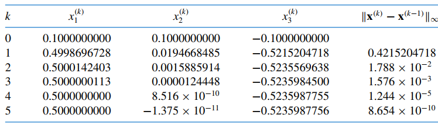

## Using Newton's Method for solving unconstrained optimisation </center>

### **Newton method is a second ordered method by using a quadratic approximation of taylor series**

$f(X+h)=f(X)+ h^T \nabla f(x) +\frac{1}{2}h \nabla^2 f(x) h^T +O(h^3)$ \ where $\nabla^2 f(x)$ is called th Hessian matrix \ so the problem is to solve \

$Min/Max \large f(\underline{X}) $

if $\nabla^2 f(X)>0 ∀ x $ then $f(X)$ a convex function , so only one extreme point is the optimum point Hessian matrix $\nabla^2 f(X)$ is positive definate

Assume that $f(X)$ is continous and at least twice diffrentiable

$ \nabla f(X^*)=\underline{0}$ whe $X^*$ is an extreme point(maximum , minimum , or sadle point) \

the itertive step equation $x_{n+1}=x_n-t\nabla^2 f^{-1}(x_n) \nabla f(x_n)$ \ where $t$ is the line search step size, for simplicity take $t=1$

So here we solve system of nonlinear equations $\nabla f(x_i)=0$

## Example 3

### Solve the problem:

### Min $ f(X)=(x_1+5)^2+(x_2+8)^2+(x_3+7)^2+2x_1^2x_2^2+4x_1^2x_3^2 \\ X_0=([1 ,1 ,1],[-2.3,0,0],[0,2,-12])$

```python
Vars = symbols('x1 x2 x3')
x1=Vars[0]
x2=Vars[1]
x3=Vars[2]
print(Vars)
f=(x1+5)**2+(x2+8)**2+(x3+7)**2+2*x1**2*x2**2+4*x1**2*x3**2
F=[f.diff(x1),f.diff(x2),f.diff(x3)]
print(F)
```

```
(x1, x2, x3)
[4*x1*x2**2 + 8*x1*x3**2 + 2*x1 + 10, 4*x1**2*x2 + 2*x2 + 16, 8*x1**2*x3 + 2*x3 + 14]
```

```python
Jacobian=Get_Jacobian(F,Vars)
print("Hessian matrix =",Jacobian)
Grad_Vec = lambdify(Vars, F,'numpy')
Hessian_Mat=lambdify(Vars,Jacobian,'numpy')
f=lambdify(Vars,f,'numpy')
```

```
Hessian matrix = [[4*x2**2 + 8*x3**2 + 2, 8*x1*x2, 16*x1*x3], [8*x1*x2, 4*x1**2 + 2, 0], [16*x1*x3, 0, 8*x1**2 + 2]]
```

```python
print((printing.latex(Jacobian)))
```

```
\left[ \left[ 4 x_{2}^{2} + 8 x_{3}^{2} + 2, \  8 x_{1} x_{2}, \  16 x_{1} x_{3}\right], \  \left[ 8 x_{1} x_{2}, \  4 x_{1}^{2} + 2, \  0\right], \  \left[ 16 x_{1} x_{3}, \  0, \  8 x_{1}^{2} + 2\right]\right]
```

$\left[ \left[ 4 x_{2}^{2} + 8 x_{3}^{2} + 2, \ 8 x_{1} x_{2}, \ 16 x_{1} x_{3}\right], \ \left[ 8 x_{1} x_{2}, \ 4 x_{1}^{2} + 2, \ 0\right], \ \left[ 16 x_{1} x_{3}, \ 0, \ 8 x_{1}^{2} + 2\right]\right] $

```python
x_intial=np.array([[1,1,1],[-2.3,0,0],[0,2,-12],[-5,-5,-5]])
Tolerance=10**-6
a,b,c=Results(Grad_Vec,Hessian_Mat,x_intial,Tolerance,'yes')
```

```
Intial point is [1. 1. 1.]
Iteration 1 , the current value [-0.96407186 -0.04790419  1.74251497] norm_diff 1.9640718562874249
Iteration 2 , the current value [ 0.43468778 -2.88869335  2.50084213] norm_diff 2.840789160234061
Iteration 3 , the current value [-0.53995405 -9.35865226  0.84072238] norm_diff 6.469958905946299
Iteration 4 , the current value [-0.42064739 -6.57667661 -3.03144681] norm_diff 3.872169188607735
Iteration 5 , the current value [-2.29281978  9.39307372  7.08447768] norm_diff 15.969750330059085
Iteration 6 , the current value [-1.35492455  6.32239947  5.21502717] norm_diff 3.0706742477176032
Iteration 7 , the current value [-0.53288883  4.31699738  4.73049166] norm_diff 2.005402092595598
Iteration 8 , the current value [ 1.05393065  4.21047983 11.7051262 ] norm_diff 6.974634540852902
Iteration 9 , the current value [0.45525354 0.81533916 9.56887055] norm_diff 3.3951406700183346
Iteration 10 , the current value [-0.56715472 -4.58249016 15.65372616] norm_diff 6.084855613695396
Iteration 11 , the current value [ 0.0342583  -8.67278819 15.61893726] norm_diff 4.090298022341468
Iteration 12 , the current value [ 0.08291137 -7.92357905 -7.17458434] norm_diff 22.79352160187005
Iteration 13 , the current value [-0.01839714 -8.15411289 -7.28187952] norm_diff 0.23053383817641215
Iteration 14 , the current value [-0.01561412 -7.99625721 -6.99351468] norm_diff 0.2883648396683336
Iteration 15 , the current value [-0.015408   -7.99620398 -6.99336012] norm_diff 0.0002061216676140544
Iteration 16 , the current value [-0.015408   -7.9962033  -6.99335893] norm_diff 1.1892743163599562e-06
Iteration 17 , the current value [-0.015408   -7.9962033  -6.99335893] norm_diff 9.645062526431047e-16
Convargence

Intial point is [-2.3  0.   0. ]
Iteration 1 , the current value [-5.         -0.69084629 -0.31588448] norm_diff 2.7
Iteration 2 , the current value [-3.74584312 -0.49663907 -0.22620542] norm_diff 1.2541568847582538
Iteration 3 , the current value [-2.76761477 -0.5257367  -0.23861657] norm_diff 0.9782283470037245
Iteration 4 , the current value [-2.4528155  -0.60248466 -0.27381423] norm_diff 0.31479926336009756
Iteration 5 , the current value [-2.48910049 -0.59738731 -0.27149351] norm_diff 0.03628498149392989
Iteration 6 , the current value [-2.48893452 -0.59747908 -0.27153695] norm_diff 0.00016597029517351203
Iteration 7 , the current value [-2.48893456 -0.59747906 -0.27153694] norm_diff 4.8209499947660106e-08
Convargence

Intial point is [  0.   2. -12.]
Iteration 1 , the current value [-0.00854701 -8.         -7.        ] norm_diff 10.0
Iteration 2 , the current value [-0.01539501 -7.99695866 -6.99467844] norm_diff 0.00684800342107081
Iteration 3 , the current value [-0.01540799 -7.9962033  -6.99335893] norm_diff 0.001319506487437394
Iteration 4 , the current value [-0.015408   -7.9962033  -6.99335893] norm_diff 5.664779756386906e-09
Convargence

Intial point is [-5. -5. -5.]
Iteration 1 , the current value [-3.36675837 -3.35929732 -3.30344877] norm_diff 1.6965512263670566
Iteration 2 , the current value [-2.3363932  -2.3072749  -2.12940296] norm_diff 1.1740458094526387
Iteration 3 , the current value [-1.78628758 -1.66661436 -1.26537458] norm_diff 0.8640283881940727
Iteration 4 , the current value [-1.70380988 -1.21682359 -0.61696061] norm_diff 0.6484139686565062
Iteration 5 , the current value [-2.04399836 -0.76092925 -0.32819835] norm_diff 0.4558943313908044
Iteration 6 , the current value [-2.43372601 -0.59592252 -0.27713013] norm_diff 0.3897276557194136
Iteration 7 , the current value [-2.48982627 -0.59742502 -0.27123268] norm_diff 0.05610026079996855
Iteration 8 , the current value [-2.48893401 -0.59747934 -0.27153688] norm_diff 0.0008922592333369117
Iteration 9 , the current value [-2.48893456 -0.59747906 -0.27153694] norm_diff 5.51911399693239e-07
Convargence
```

```python
#checking the gradient objective function be zero

# x_min=c[0]
# f_min=F(*x_min)
# print(f_min)
# for i in range(len(c)):
#   Obj=F(*c[i])
#   print("\n")
#   print("start value ",x_intial[i])
#   print("extreme point is",c[i])
#   print("the gradient at extreme point is",Obj)
#   print("the value of objective at tha points=",F(*c[i]))
#   if Obj < f_min:
#     f_min=Obj
#     x_min=c[i]
# print("\n")
# print("The minimum value of f is {} ,X* is{} ".format(f_min,x_min))
```

```python
# find min of function from results
[x_min,f_min]=Min_func(f,Grad_Vec,c)
print("The minimum value of f is {} ,X* is{} ".format(f_min,x_min))
```

```
extreme point is [-0.015408   -7.9962033  -6.99335893]
the gradient at extreme point is [0.0, 0.0, 0.0]
the value of objective at tha points= 24.923018533267275


extreme point is [-2.48893456 -0.59747906 -0.27153694]
the gradient at extreme point is [3.552713678800501e-15, 1.0658141036401503e-14, 7.105427357601002e-15]
the value of objective at tha points= 112.62485852492722


extreme point is [-0.015408   -7.9962033  -6.99335893]
the gradient at extreme point is [3.552713678800501e-15, 0.0, 0.0]
the value of objective at tha points= 24.923018533267275


extreme point is [-2.48893456 -0.59747906 -0.27153694]
the gradient at extreme point is [-2.5934809855243657e-13, 2.348343741687131e-12, -1.9877433032888803e-12]
the value of objective at tha points= 112.62485852492723


The minimum value of f is 24.923018533267275 ,X* is[-0.015408   -7.9962033  -6.99335893]
```

This point may or not to ba a global minimization, so we can intialize by random vectors to get closer to global minima

```python
# generate random intial vectors
x_intial=np.random.rand(5,3)
print(x_intial)
Tolerance=10**-6
a,b,c=Results(Grad_Vec,Hessian_Mat,x_intial,Tolerance,'no')
```

```
[[0.56901815 0.68951555 0.6594913 ]
 [0.03865782 0.40828265 0.01520586]
 [0.14162938 0.93654467 0.20971532]
 [0.14391858 0.44240127 0.6601634 ]
 [0.8055707  0.45631209 0.93963355]]

Intial point is [0.56901815 0.68951555 0.6594913 ]
Convargence

Intial point is [0.03865782 0.40828265 0.01520586]
Convargence

Intial point is [0.14162938 0.93654467 0.20971532]
Convargence

Intial point is [0.14391858 0.44240127 0.6601634 ]
Convargence

Intial point is [0.8055707  0.45631209 0.93963355]
Convargence
```

```python
# find min of function from results
[x_min,f_min]=Min_func(f,Grad_Vec,c)
print("The minimum value of f is {} ,X* is{} ".format(f_min,x_min))
```

```
extreme point is [-2.48893456 -0.59747906 -0.27153694]
the gradient at extreme point is [0.0, 0.0, 1.7763568394002505e-15]
the value of objective at tha points= 112.62485852492719


extreme point is [-2.48893456 -0.59747906 -0.27153694]
the gradient at extreme point is [0.0, 0.0, 1.7763568394002505e-15]
the value of objective at tha points= 112.62485852492722


extreme point is [-2.48893456 -0.59747906 -0.27153694]
the gradient at extreme point is [0.0, 0.0, 1.7763568394002505e-15]
the value of objective at tha points= 112.62485852492719


extreme point is [-2.48893456 -0.59747906 -0.27153694]
the gradient at extreme point is [-1.0103917702508625e-11, -3.147704319417244e-12, 3.057820663343591e-11]
the value of objective at tha points= 112.62485852492722


extreme point is [-2.48893456 -0.59747906 -0.27153694]
the gradient at extreme point is [0.0, 7.034373084024992e-13, -5.666578317686799e-13]
the value of objective at tha points= 112.62485852492722


The minimum value of f is 112.62485852492719 ,X* is[-2.48893456 -0.59747906 -0.27153694]
```

## Example 4

### Solve the problem:

### Min $ f(X)=(x_1+10x_2)^2+5(x_3-x_4)^2+(x_2-2x_3)^4+100(x_1-x_4)^4\\ X_0=([-2 ,-1 ,1,2],[200,-200,100,-100])$

```python
Vars = symbols('x1 x2 x3 x4')
x1=Vars[0]
x2=Vars[1]
x3=Vars[2]
x4=Vars[3]
print(Vars)
f=(x1+10*x2)**2+5*(x3-x4)**2+(x2-2*x3)**4+100*(x1-x4)**4
F=[f.diff(x1),f.diff(x2),f.diff(x3),f.diff(x4)]
print(F)
```

```
(x1, x2, x3, x4)
[2*x1 + 20*x2 + 400*(x1 - x4)**3, 20*x1 + 200*x2 + 4*(x2 - 2*x3)**3, 10*x3 - 10*x4 - 8*(x2 - 2*x3)**3, -10*x3 + 10*x4 - 400*(x1 - x4)**3]
```

```python
Jacobian=Get_Jacobian(F,Vars)
print("Hessian matrix =",Jacobian)
Grad_Vec = lambdify(Vars, F,'numpy')
Hessian_Mat=lambdify(Vars,Jacobian,'numpy')
f=lambdify(Vars,f,'numpy')
```

```
Hessian matrix = [[1200*(x1 - x4)**2 + 2, 20, 0, -1200*(x1 - x4)**2], [20, 12*(x2 - 2*x3)**2 + 200, -24*(x2 - 2*x3)**2, 0], [0, -24*(x2 - 2*x3)**2, 48*(x2 - 2*x3)**2 + 10, -10], [-1200*(x1 - x4)**2, 0, -10, 1200*(x1 - x4)**2 + 10]]
```

```python
x_intial=np.array([[-2,-1,1,2],[200,-200,100,-100],[100,-100,100,-100]])
#x_intial=np.array([[3.4,2.2],[1,1],[1,-5],[10,10],[2,-10],[2000,2000],[3.4,2.2],[4,4],[1,1],[20,20]])
Tolerance=10**-6
a,b,c=Results(Grad_Vec,Hessian_Mat,x_intial,Tolerance,'yes')
```

```
Intial point is [-2 -1  1  2]
Iteration 1 , the current value [-1.58730159  0.15873016  1.07936508  1.07936508] norm_diff 1.1587301587301226
Iteration 2 , the current value [-1.05820106  0.10582011  0.71957672  0.71957672] norm_diff 0.529100529100333
Iteration 3 , the current value [-0.70546737  0.07054674  0.47971781  0.47971781] norm_diff 0.3527336860668129
Iteration 4 , the current value [-0.47031158  0.04703116  0.31981188  0.31981188] norm_diff 0.23515579071143122
Iteration 5 , the current value [-0.31354105  0.03135411  0.21320792  0.21320792] norm_diff 0.1567705271408819
Iteration 6 , the current value [-0.20902737  0.02090274  0.14213861  0.14213861] norm_diff 0.10451368476058498
Iteration 7 , the current value [-0.13935158  0.01393516  0.09475907  0.09475907] norm_diff 0.06967578984039324
Iteration 8 , the current value [-0.09290105  0.00929011  0.06317272  0.06317272] norm_diff 0.046450526560263494
Iteration 9 , the current value [-0.06193404  0.0061934   0.04211514  0.04211514] norm_diff 0.030967017706841737
Iteration 10 , the current value [-0.04128936  0.00412894  0.02807676  0.02807676] norm_diff 0.020644678471227973
Iteration 11 , the current value [-0.02752624  0.00275262  0.01871784  0.01871784] norm_diff 0.013763118980818834
Iteration 12 , the current value [-0.01835083  0.00183508  0.01247856  0.01247856] norm_diff 0.009175412653879
Iteration 13 , the current value [-0.01223388  0.00122339  0.00831904  0.00831904] norm_diff 0.006116941769252537
Iteration 14 , the current value [-0.00815592  0.00081559  0.00554603  0.00554603] norm_diff 0.004077961179501766
Iteration 15 , the current value [-0.00543728  0.00054373  0.00369735  0.00369735] norm_diff 0.0027186407863351025
Iteration 16 , the current value [-0.00362485  0.00036249  0.0024649   0.0024649 ] norm_diff 0.0018124271908882966
Iteration 17 , the current value [-0.00241657  0.00024166  0.00164327  0.00164327] norm_diff 0.0012082847939262203
Iteration 18 , the current value [-0.00161105  0.0001611   0.00109551  0.00109551] norm_diff 0.0008055231959524373
Iteration 19 , the current value [-0.00107403  0.0001074   0.00073034  0.00073034] norm_diff 0.0005370154639636748
Iteration 20 , the current value [-7.16020619e-04  7.16020619e-05  4.86894021e-04  4.86894021e-04] norm_diff 0.0003580103093067562
Iteration 21 , the current value [-4.77347079e-04  4.77347079e-05  3.24596014e-04  3.24596014e-04] norm_diff 0.00023867353954192677
Iteration 22 , the current value [-3.18231386e-04  3.18231386e-05  2.16397343e-04  2.16397343e-04] norm_diff 0.00015911569303650626
Iteration 23 , the current value [-2.12154257e-04  2.12154257e-05  1.44264895e-04  1.44264895e-04] norm_diff 0.00010607712870866742
Iteration 24 , the current value [-1.41436172e-04  1.41436172e-05  9.61765967e-05  9.61765967e-05] norm_diff 7.07180857607917e-05
Iteration 25 , the current value [-9.42907811e-05  9.42907811e-06  6.41177311e-05  6.41177311e-05] norm_diff 4.714539049358035e-05
Iteration 26 , the current value [-6.28605207e-05  6.28605207e-06  4.27451541e-05  4.27451541e-05] norm_diff 3.1430260428308085e-05
Iteration 27 , the current value [-4.19070138e-05  4.19070138e-06  2.84967694e-05  2.84967694e-05] norm_diff 2.095350690944713e-05
Iteration 28 , the current value [-2.79380091e-05  2.79380091e-06  1.89978464e-05  1.89978464e-05] norm_diff 1.3969004682396684e-05
Iteration 29 , the current value [-1.86253392e-05  1.86253392e-06  1.26652311e-05  1.26652311e-05] norm_diff 9.312669876830257e-06
Iteration 30 , the current value [-1.24168927e-05  1.24168927e-06  8.44348751e-06  8.44348751e-06] norm_diff 6.208446492870514e-06
Iteration 31 , the current value [-8.27792811e-06  8.27792811e-07  5.62899203e-06  5.62899203e-06] norm_diff 4.138964590137955e-06
Iteration 32 , the current value [-5.51861875e-06  5.51861875e-07  3.75266135e-06  3.75266135e-06] norm_diff 2.7593093599188043e-06
Iteration 33 , the current value [-3.67907898e-06  3.67907898e-07  2.50177443e-06  2.50177443e-06] norm_diff 1.8395397721970527e-06
Iteration 34 , the current value [-2.45271874e-06  2.45271874e-07  1.66785020e-06  1.66785020e-06] norm_diff 1.2263602349797225e-06
Iteration 35 , the current value [-1.63514915e-06  1.63514915e-07  1.11189681e-06  1.11189681e-06] norm_diff 8.175695896436215e-07
Convargence

Intial point is [ 200 -200  100 -100]
Iteration 1 , the current value [431.08379069 -43.10837908 111.7791438  111.7791436 ] norm_diff 231.0837906897068
```

[output cut: 85 more lines]

```
Iteration 35 , the current value [ 3.16706750e-04 -3.16706750e-05  8.71788857e-05  8.71788857e-05] norm_diff 0.00015835337496762723
Iteration 36 , the current value [ 2.11137833e-04 -2.11137833e-05  5.81192571e-05  5.81192571e-05] norm_diff 0.00010556891665360448
Iteration 37 , the current value [ 1.40758556e-04 -1.40758556e-05  3.87461715e-05  3.87461715e-05] norm_diff 7.03792776900504e-05
Iteration 38 , the current value [ 9.38390371e-05 -9.38390371e-06  2.58307810e-05  2.58307810e-05] norm_diff 4.6919518445205145e-05
Iteration 39 , the current value [ 6.25593580e-05 -6.25593580e-06  1.72205206e-05  1.72205206e-05] norm_diff 3.127967909545733e-05
Iteration 40 , the current value [ 4.17062387e-05 -4.17062387e-06  1.14803471e-05  1.14803471e-05] norm_diff 2.0853119310085776e-05
Iteration 41 , the current value [ 2.78041592e-05 -2.78041592e-06  7.65356478e-06  7.65356478e-06] norm_diff 1.390207951933143e-05
Iteration 42 , the current value [ 1.85361062e-05 -1.85361062e-06  5.10237663e-06  5.10237663e-06] norm_diff 9.268052953738176e-06
Iteration 43 , the current value [ 1.23574039e-05 -1.23574039e-06  3.40158417e-06  3.40158417e-06] norm_diff 6.178702315907085e-06
Iteration 44 , the current value [ 8.23826906e-06 -8.23826906e-07  2.26772255e-06  2.26772255e-06] norm_diff 4.1191348448183955e-06
Iteration 45 , the current value [ 5.49217986e-06 -5.49217986e-07  1.51181547e-06  1.51181547e-06] norm_diff 2.7460892011885334e-06
Iteration 46 , the current value [ 3.66145202e-06 -3.66145202e-07  1.00787569e-06  1.00787569e-06] norm_diff 1.830727841233492e-06
Iteration 47 , the current value [ 2.44096758e-06 -2.44096758e-07  6.71916756e-07  6.71916756e-07] norm_diff 1.2204844420152996e-06
Iteration 48 , the current value [ 1.62731674e-06 -1.62731674e-07  4.47949541e-07  4.47949541e-07] norm_diff 8.136508335996538e-07
Convargence
```

```python
# find min of function from results
[x_min,f_min]=Min_func(f,Grad_Vec,c)
print("The minimum value of f is {} ,X* is{} ".format(f_min,x_min))
```

```
extreme point is [-1.63514915e-06  1.63514915e-07  1.11189681e-06  1.11189681e-06]
the gradient at extreme point is [-8.291974278417957e-15, -3.501533964213432e-17, 6.996291664848829e-17, 8.291970890286168e-15]
the value of objective at tha points= 5.712624175846255e-21


extreme point is [ 1.52117757e-06 -1.52117757e-07  3.94434871e-07  3.94434871e-07]
the gradient at extreme point is [5.721795332215548e-16, -3.3599227116603614e-18, 6.6656353146964476e-18, -5.721820743203966e-16]
the value of objective at tha points= 1.6195952844918804e-22


extreme point is [ 1.62731674e-06 -1.62731674e-07  4.47949541e-07  4.47949541e-07]
the gradient at extreme point is [6.561577305462995e-16, -4.732073529417793e-18, 9.457370795257551e-18, -6.561221551625148e-16]
the value of objective at tha points= 1.9471819354128212e-22


The minimum value of f is 1.6195952844918804e-22 ,X* is[ 1.52117757e-06 -1.52117757e-07  3.94434871e-07  3.94434871e-07]
```

This point may or not to ba a global minimization, so we can intialize by random vectors to get closer to global minima

```python
# generate random intial vectors
x_intial=np.random.rand(2,4)
print(x_intial)
Tolerance=10**-6
a,b,c=Results(Grad_Vec,Hessian_Mat,x_intial,Tolerance,'no')
```

```
[[0.98099149 0.60714295 0.86282096 0.12668362]
 [0.53689914 0.07490981 0.25061447 0.5037221 ]]

Intial point is [0.98099149 0.60714295 0.86282096 0.12668362]
Convargence

Intial point is [0.53689914 0.07490981 0.25061447 0.5037221 ]
Convargence
```

```python
# find min of function from results
[x_min,f_min]=Min_func(f,Grad_Vec,c)
print("The minimum value of f is {} ,X* is{} ".format(f_min,x_min))
```

```
extreme point is [ 1.38682308e-06 -1.38682308e-07  5.06764296e-07  5.06764296e-07]
the gradient at extreme point is [2.7264174027148984e-16, -6.135595145081168e-18, 1.222883864279962e-17, -2.726349640079118e-16]
the value of objective at tha points= 6.174805770610967e-23


extreme point is [ 1.83523428e-06 -1.83523428e-07  1.57570780e-06  1.57570780e-06]
the gradient at extreme point is [6.992481757987464e-18, -1.4835556661284184e-16, 2.9672807388462877e-16, -6.995446373302854e-18]
the value of objective at tha points= 1.2414849766846272e-22


The minimum value of f is 6.174805770610967e-23 ,X* is[ 1.38682308e-06 -1.38682308e-07  5.06764296e-07  5.06764296e-07]
```

## Example 5

### Solve the problem:

### Min $ f(X)=-x_2^2e^{1-x_1^2-20(x_1-x_2)^2} \\ X_0=([0.1 ,0.1],[0.8,0.1],[1.1,0.1])$ with $ϵ=10^{-6}$

```python
Vars = symbols('x1 x2 ')
x1=Vars[0]
x2=Vars[1]
print(Vars)
f=-x2**2*E**(1-x1**2-20*(x1-x2)**2)
print(f)
F=[f.diff(x1),f.diff(x2)]
print(F)
```

```
(x1, x2)
-x2**2*exp(-x1**2 - 20*(x1 - x2)**2 + 1)
[-x2**2*(-42*x1 + 40*x2)*exp(-x1**2 - 20*(x1 - x2)**2 + 1), -x2**2*(40*x1 - 40*x2)*exp(-x1**2 - 20*(x1 - x2)**2 + 1) - 2*x2*exp(-x1**2 - 20*(x1 - x2)**2 + 1)]
```

```python
Jacobian=Get_Jacobian(F,Vars)
print("Hessian matrix =",Jacobian)
Grad_Vec = lambdify(Vars, F,'numpy')
Hessian_Mat=lambdify(Vars,Jacobian,'numpy')
f=lambdify(Vars,f,'numpy')
```

[output not shown]

```python
x_intial=np.array([[0.1,0.1],[0.8,0.1],[1.1,0.1]])
#x_intial=np.array([[3.4,2.2],[1,1],[1,-5],[10,10],[2,-10],[2000,2000],[3.4,2.2],[4,4],[1,1],[20,20]])
Tolerance=10**-6
Results(Grad_Vec,Hessian_Mat,x_intial,Tolerance,'no')
```

```
Intial point is [0.1 0.1]
Divargence!

Intial point is [0.8 0.1]
Divargence!

Intial point is [1.1 0.1]
Divargence!
```

```
([683, 703, 692], ['Divargence', 'Divargence', 'Divargence'], [])
```

For this problem newton's method Divarge!

## **QR factorization using Gram–Schmidt**

## Example 6 Factorise the matrtics

$A= \begin{bmatrix} 1 & 1 & 0\\ 1 & 0 & 1\\ 0 & 1 & 1 \end{bmatrix} B=\begin{bmatrix} 1 & -1 & 4\\ 1 & 4 & -2\\ 1 & 4 & 2\\ 1 & -1 & 0 \end{bmatrix}$

```python
A=np.array([[1,1,0],[1,0,1],[0,1,1]])
B=np.array([[1,-1,4],[1,4,-2],[1,4,2],[1,-1,0]])
C=np.array([[-1,-1,1],[1,3,3],[-1,-1,5],[1,3,7]])
L=[A,B,C]



for Mat in L:
  [Q,R]=Gram_Schmidt_QR(Mat)
  print("Matrix \n",Mat)
  print("Orthonormal Q matrix \n",Q)
  print("Upper matrix R\n",R)
```

```
Matrix
 [[1 1 0]
 [1 0 1]
 [0 1 1]]
Orthonormal Q matrix
 [[ 0.70710678  0.40824829 -0.57735027]
 [ 0.70710678 -0.40824829  0.57735027]
 [ 0.          0.81649658  0.57735027]]
Upper matrix R
 [[1.41421356 0.70710678 0.70710678]
 [0.         1.22474487 0.40824829]
 [0.         0.         1.15470054]]
Matrix
 [[ 1 -1  4]
 [ 1  4 -2]
 [ 1  4  2]
 [ 1 -1  0]]
Orthonormal Q matrix
 [[ 0.5 -0.5  0.5]
 [ 0.5  0.5 -0.5]
 [ 0.5  0.5  0.5]
 [ 0.5 -0.5 -0.5]]
Upper matrix R
 [[ 2.  3.  2.]
 [ 0.  5. -2.]
 [ 0.  0.  4.]
 [ 0.  0.  0.]]
Matrix
 [[-1 -1  1]
 [ 1  3  3]
 [-1 -1  5]
 [ 1  3  7]]
Orthonormal Q matrix
 [[-0.5  0.5 -0.5]
 [ 0.5  0.5 -0.5]
 [-0.5  0.5  0.5]
 [ 0.5  0.5  0.5]]
Upper matrix R
 [[2. 4. 2.]
 [0. 2. 8.]
 [0. 0. 4.]
 [0. 0. 0.]]
```

```python
# compare to built in function
import scipy.linalg
for Mat in L:
  Q, R = scipy.linalg.qr(Mat)
  print("Matrix \n",Mat)
  print("Orthonormal Q matrix \n",Q)
  print("Upper matrix R\n",R)
# extrac naegative sign in R matrix!
```

```
Matrix
 [[1 1 0]
 [1 0 1]
 [0 1 1]]
Orthonormal Q matrix
 [[-0.70710678  0.40824829 -0.57735027]
 [-0.70710678 -0.40824829  0.57735027]
 [-0.          0.81649658  0.57735027]]
Upper matrix R
 [[-1.41421356 -0.70710678 -0.70710678]
 [ 0.          1.22474487  0.40824829]
 [ 0.          0.          1.15470054]]
Matrix
 [[ 1 -1  4]
 [ 1  4 -2]
 [ 1  4  2]
 [ 1 -1  0]]
Orthonormal Q matrix
 [[-0.5  0.5 -0.5 -0.5]
 [-0.5 -0.5  0.5 -0.5]
 [-0.5 -0.5 -0.5  0.5]
 [-0.5  0.5  0.5  0.5]]
Upper matrix R
 [[-2. -3. -2.]
 [ 0. -5.  2.]
 [ 0.  0. -4.]
 [ 0.  0.  0.]]
Matrix
 [[-1 -1  1]
 [ 1  3  3]
 [-1 -1  5]
 [ 1  3  7]]
Orthonormal Q matrix
 [[-0.5 -0.5  0.5  0.5]
 [ 0.5 -0.5  0.5 -0.5]
 [-0.5 -0.5 -0.5 -0.5]
 [ 0.5 -0.5 -0.5  0.5]]
Upper matrix R
 [[ 2.  4.  2.]
 [ 0. -2. -8.]
 [ 0.  0. -4.]
 [ 0.  0.  0.]]
```

### References

1. Intermediate Numerical Analysis by Prof.Dr.Hassan Nasr Ahmed Ismail
2. Numerical Analysis by Richard L.Burden & J.Douglas Faires 9th edition
3. Practical Optimisation Algorithms And Engineering Applications by Andreas Antoniou & Wu_Sheng Lu